რმაRგ: მეოთხე შეხვედრა

# რაოდენობრივ მონაცემთა ანალიზი R-გარემოში

დავით სიჭინავა  
5 აპრილი, 2019

### დღევანდელი შეხვედრის გეგმა

- ალბათობა

### რატომ გვჭირდება ალბათობა?

- მონაცემთა ანალიზი მოიცავს როგორც *მონაცემებიდან* ლოგიკური სტრუქტურის გამოყოფას, ასევე - იმ *განუსაზღვრელობის დონის* დადგენას, თუ როგორ ვართ დარწმუნებული საკუთარ დასკვნაში
- ალბათობა პირველ რიგში *განუსაზღვრელობის დონის* შეფასებისთვის გვჭირდება, თუმცა გარდა ამისა, იგი გვეხმარება, შევისწავლოთ *მონაცემთა გენერირების პროცესიც*

### რა არის ალბათობა?

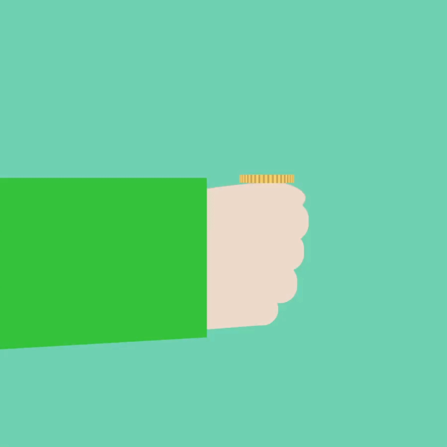

### რა არის ალბათობა? _ფრიკვენტისტული (სიხშირული)_ ინტერპრეტაცია

- ალბათობა წარმოადგენს *ფარდობითი სიხშირის* ზედა ზღვარს, რომელიც განისაზღვრება ხდომილებების რაოდენობასა და ცდების საერთო რაოდენობებს შორის შეფარდებით.
- თუ მონეტის აგდება ერთნაირ პირობებში ხდება, ავერსის მოსვლის რაოდენობების წილი აგდებების რაოდენობის ზრდასთან ერთად 0.5-ს უახლოვდება

### რა შეიძლება იყოს პრობლემატური ფრიკვენტისტულ ინტერპრეტაციაში?

- რა არის ,,მსგავსი პირობები''?
- რამდენად რეალისტურია პრაქტიკაში უსასრულოდ ბევრი ერთნაირი ექსპერიმენტის ჩატარება?

### რა არის ალბათობა? _ბაიესური_ ინტერპრეტაცია

[figure not shown]

### რა არის ალბათობა? _ბაიესური_ ინტერპრეტაცია

- ალბათობა წარმოადგენს ინდივიდის *სუბიექტურ* რწმენას, ამა თუ იმ მოვლენის მოხდენის *დასაჯერებლობასთან* დაკავშირებით
  - თუ ალბათობა ნულის ტოლია, ეს ნიშნავს, რომ ადამიანს რაიმე მოვლენის მოხდენის საერთოდ არ სჯერა;
  - თუ ალბათობა ერთის ტოლია, ადამიანი აბსოლუტურად დარწმუნებულია რაიმე მოვლენის მოხდენაში;

### რა შეიძლება იყოს პრობლემატური ბაიესურ ინტერპრეტაციაში?

- თუ გვაქვს იდენტური ემპირიული პირობები, მაშინ ექსპერიმენტის შედეგად ზუსტად მსგავს შედეგებამდე უნდა მივიდეთ;
- ამან შეიძლება, შეაფერხოს სამეცნიერო პროგრესი, რადგან კვლევის შედეგების ინტერპრეტაცია დაეფუძნება არა მყარ ემპირიკას, არამედ - ადამიანის ღირებულებათა სისტემას

### ალბათობის აქსიომები

- ნებისმიერი A ხდომილების ალბათობა არაუარყოფითია:
  - \( P(A)\geqslant0 \)
- ალბათობა იმისა, რომ ხდომილება ხდება ხდომილებათა სივრცეში, 1-ის ტოლია:
  - \( P(\Omega)=1 \)
- თუ ხდომილებები \( A \) და \( B \) ურთიერთგამომრიცხავია, მაშინ მართებულია ტოლობა:
  - \( P(A or B) = P(A) + P(B) \)

### დაბადების დღის პრობლემა

[figure not shown]

### დაბადების დღის პრობლემა

- რამდენი ადამიანი გვჭირდება იმისთვის, რომ ორ მათგანს მაინც ერთ დღეს ჰქონდეს დაბადების დღე?

### დაბადების დღის პრობლემა

\( P(ორ\qquadადამიანს\qquadმაინც\qquadაქვს\qquadდაბადების\qquadდღე)=1-P(არავის\qquadაქვს\qquadდაბადების\qquadდღე) \)

### დაბადების დღის პრობლემა

\( log(P(NoBirthday))=log(365)!-k*log(365)-log(365-k)! \)

### დაბადების დღის პრობლემა

```r
birthday <- function(k) {
logdenom <- k * log(365) + lfactorial(365 - k)
lognumer <- lfactorial(365)
pr <- 1 - exp(lognumer - logdenom)
return(pr)
}
k <- 1:50
bday <- birthday(k)
plot(k, bday, xlab = "Number of people", xlim = c(0, 50), ylim = c(0, 1),
ylab = "Probability that at least two\n people have the same birthday")
abline(h = 0.5)
bday[20:25]
```

[output not shown]